# IE582 HOMEWORK 1

Eylül Güllü / 2021402255

**INTRODUCTION** This project focuses on modeling high frequency communication systems, especially 5G antenna design. The aim of the project is to understand and predict the relationship between S11 (return loss) parameters, which determine the performance of the antenna, and the antenna geometry. The given data sets consist of 385 antenna designs simulated according to 11 design parameters and each design consists of measurements at 201 different frequency values. Using this data, the effects of design parameters on antenna performance will be analyzed by dimensionality reduction (PCA) and regression modeling methods.

**Data Preparation:** First, I defined the necessary libraries and loaded the given data sets. Before starting the modeling, I checked if there were any missing values in the data sets and if the data numbers were consistent with each other. As we can see from the outputs, there are no problems in our data that would prevent us from performing analysis.

```r
#Libraries
library(tidyverse)
library(naniar)
library(ggcorrplot)
library(caret)

#Data Sets Upload
setwd("/Users/eylulruyagullu/Desktop/BOUN'4/IE582/hw1_files")
input_data <- read.csv("hw1_input.csv", header = TRUE)
real_data <- read.csv("hw1_real.csv", header = TRUE)
img_data <- read.csv("hw1_img.csv", header = TRUE)

#Missing Data Control
cat("Input Data Missing Values:", sum(is.na(input_data)), "\n")
```

```
Input Data Missing Values: 0
```

```r
cat("Real Part Data Missing Values:", sum(is.na(real_data)), "\n")
```

```
Real Part Data Missing Values: 0
```

```r
cat("Imaginary Part Data Missing Values:", sum(is.na(img_data)), "\n")
```

```
Imaginary Part Data Missing Values: 0
```

```r
#Number of Rows Control
cat("Input Data Row Count:", nrow(input_data), "\n")
```

```
Input Data Row Count: 385
```

```r
cat("Real Part Data Row Count:", nrow(real_data), "\n")
```

```
Real Part Data Row Count: 385
```

```r
cat("Imaginary Part Data Row Count:", nrow(img_data), "\n")
```

```
Imaginary Part Data Row Count: 385
```

**Frequency Selection:** As we can see in the S11 output files, measurements were made according to the given parameters at 201 different frequency points in the 23-33 GHz range. Since establishing 201 separate models (or covering the characteristics of 201 frequency values) and multitarget linear regression are outside the scope of our course, I will establish linear regression models for certain selected frequency values and analyze their performances. Since a small S11 value is an indicator that the system performs better, I selected these critical frequency values according to the size of the S11 values. We have two output files: real and imaginary. These two parts show the values affected by different variables, but while commenting on the size of the general S11 value, I proceeded by finding the euclidean distance between these two points. Then, I found the variance of these distances, which I defined as s11_magnitude for the columns corresponding to each frequency value. To enhance the model construction process, I shifted the focus to identifying frequency values where the variance in S11 values is highest. This is based on the assumption that frequencies with higher variance indicate that the corresponding input features have a more significant influence on the S11 output. By selecting these frequencies, the model will better account for the input parameters that most affect the S11 values.

```r
frequencies <- seq(23, 33, length.out = ncol(real_data))

s11_magnitude <- sqrt(real_data^2 + img_data^2)
column_variances <- apply(s11_magnitude, 2, var)
selected_indices <- order(column_variances, decreasing = TRUE)[1:4]
selected_frequencies <- frequencies[selected_indices]

real_selected <- real_data[, selected_indices]
img_selected <- img_data[, selected_indices]

selected_frequencies
```

```
[1] 30.30 30.25 30.35 30.20
```

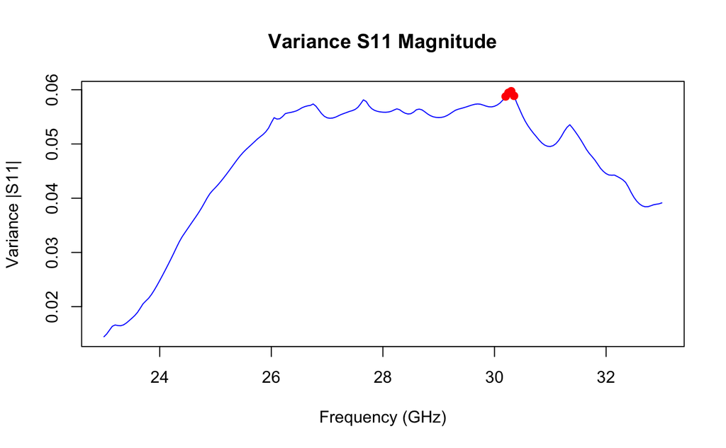

```r
plot(frequencies, column_variances, type = "l", col = "blue",
     xlab = "Frequency (GHz)", ylab = "Variance |S11|", main = "Variance S11 Magnitude")
points(selected_frequencies, column_variances[selected_indices], col = "red", pch = 19)
```

**Correlation Analysis:** It would be useful to use the intervals between our predictors before building the model. When we examine the correlation matrix, we see that there is approximately 92% agreement between the patch width and substrate height variables. This change can create multicollinearity in our model by screening one of these variables or by combining the interaction term to try to reduce a single variable.

We also see a greater than 40% appearance between the dielectric constant of the substrate and the patch width and substrate height variables. Another relationship we need to consider in model building.

```r
correlation_matrix <- cor(input_data)
print(correlation_matrix)
```

```
                                           length.of.patch width.of.patch height.of.patch height.of.substrate
length.of.patch                                1.000000000    -0.11417384     -0.02603197        -0.064343925
width.of.patch                                -0.114173838     1.00000000      0.09172574         0.923739177
height.of.patch                               -0.026031974     0.09172574      1.00000000         0.082833400
height.of.substrate                           -0.064343925     0.92373918      0.08283340         1.000000000
height.of.solder.resist.layer                  0.044501770    -0.02105555      0.03604491        -0.011870246
radius.of.the.probe                           -0.069904535     0.03567518      0.03068912         0.017410148
c_pad                                         -0.005560154    -0.04419845      0.00242201        -0.031570678
c_antipad                                     -0.009627304    -0.01335778      0.03758257        -0.009432011
c_probe                                        0.081734722     0.02999903      0.03159241         0.044165512
dielectric.constant.of.substrate              -0.037447806     0.44219338     -0.04431754         0.459846618
dielectric.constant.of.solder.resist.layer    -0.014495695     0.03874586     -0.03776888         0.002420837
                                           height.of.solder.resist.layer radius.of.the.probe        c_pad     c_antipad     c_probe
length.of.patch                                               0.04450177       -0.0699045348 -0.005560154 -0.0096273042  0.08173472
width.of.patch                                               -0.02105555        0.0356751757 -0.044198447 -0.0133577777  0.02999903
height.of.patch                                               0.03604491        0.0306891240  0.002422010  0.0375825680  0.03159241
height.of.substrate                                          -0.01187025        0.0174101485 -0.031570678 -0.0094320113  0.04416551
height.of.solder.resist.layer                                 1.00000000       -0.0127562158 -0.018044245 -0.0170706717  0.02484211
radius.of.the.probe                                          -0.01275622        1.0000000000  0.002906155 -0.0005231856  0.04808797
c_pad                                                        -0.01804425        0.0029061549  1.000000000  0.0676776845 -0.01550022
c_antipad                                                    -0.01707067       -0.0005231856  0.067677684  1.0000000000 -0.13232080
c_probe                                                       0.02484211        0.0480879748 -0.015500215 -0.1323207967  1.00000000
dielectric.constant.of.substrate                             -0.01096653       -0.0257281569 -0.049318442 -0.0167409193  0.01564016
dielectric.constant.of.solder.resist.layer                   -0.03840494        0.0075236725  0.015283927  0.0678205174 -0.02910079
                                           dielectric.constant.of.substrate dielectric.constant.of.solder.resist.layer
length.of.patch                                                 -0.03744781                               -0.014495695
width.of.patch                                                   0.44219338                                0.038745861
height.of.patch                                                 -0.04431754                               -0.037768883
height.of.substrate                                              0.45984662                                0.002420837
height.of.solder.resist.layer                                   -0.01096653                               -0.038404940
radius.of.the.probe                                             -0.02572816                                0.007523673
c_pad                                                           -0.04931844                                0.015283927
c_antipad                                                       -0.01674092                                0.067820517
c_probe                                                          0.01564016                               -0.029100791
dielectric.constant.of.substrate                                 1.00000000                                0.060401607
dielectric.constant.of.solder.resist.layer                       0.06040161                                1.000000000
```

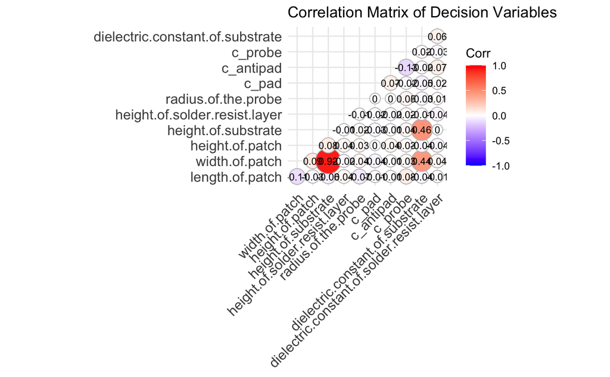

```r
ggcorrplot(correlation_matrix,
           method = "circle",
           type = "lower",
           lab = TRUE,
           lab_size = 3,
           colors = c("blue", "white", "red"),
           title = "Correlation Matrix of Decision Variables")
```

```r
real_model_26_7 <- lm(real_selected[,1] ~ ., data = input_data)
summary(real_model_26_7)
```

```
Call:
lm(formula = real_selected[, 1] ~ ., data = input_data)

Residuals:
     Min       1Q   Median       3Q      Max
-0.88019 -0.16442 -0.05953  0.12882  1.22762

Coefficients:
                                            Estimate Std. Error t value Pr(>|t|)
(Intercept)                                -1.574965   0.155401 -10.135  < 2e-16 ***
length.of.patch                             0.036802   0.015302   2.405  0.01665 *
width.of.patch                              0.129300   0.032657   3.959    9e-05 ***
height.of.patch                             1.319654   1.668240   0.791  0.42942
height.of.substrate                         1.440612   0.142144  10.135  < 2e-16 ***
height.of.solder.resist.layer               1.026801   0.614734   1.670  0.09570 .
radius.of.the.probe                        -3.407959   1.409822  -2.417  0.01612 *
c_pad                                      -2.415033   2.049389  -1.178  0.23938
c_antipad                                   0.588388   0.684449   0.860  0.39053
c_probe                                     0.019819   0.132490   0.150  0.88117
dielectric.constant.of.substrate            0.050815   0.019307   2.632  0.00884 **
dielectric.constant.of.solder.resist.layer  0.005327   0.016827   0.317  0.75175
---
Signif. codes:  0 ‘***’ 0.001 ‘**’ 0.01 ‘*’ 0.05 ‘.’ 0.1 ‘ ’ 1

Residual standard error: 0.2843 on 373 degrees of freedom
Multiple R-squared:  0.7998,    Adjusted R-squared:  0.7939
F-statistic: 135.4 on 11 and 373 DF,  p-value: < 2.2e-16
```

```r
img_model_26_7 <- lm(img_selected[,1] ~ ., data = input_data)
summary(img_model_26_7)
```

```
Call:
lm(formula = img_selected[, 1] ~ ., data = input_data)

Residuals:
     Min       1Q   Median       3Q      Max
-1.12810 -0.13649  0.05422  0.19517  0.71680

Coefficients:
                                            Estimate Std. Error t value Pr(>|t|)
(Intercept)                                 0.608715   0.160623   3.790 0.000176 ***
length.of.patch                            -0.021614   0.015816  -1.367 0.172564
width.of.patch                              0.098748   0.033755   2.925 0.003650 **
height.of.patch                             2.788452   1.724301   1.617 0.106691
height.of.substrate                        -0.934537   0.146920  -6.361 5.88e-10 ***
height.of.solder.resist.layer              -0.340017   0.635392  -0.535 0.592879
radius.of.the.probe                        -5.566197   1.457198  -3.820 0.000156 ***
c_pad                                      -0.029394   2.118258  -0.014 0.988936
c_antipad                                   0.806726   0.707450   1.140 0.254881
c_probe                                    -0.865985   0.136942  -6.324 7.31e-10 ***
dielectric.constant.of.substrate            0.023413   0.019956   1.173 0.241457
dielectric.constant.of.solder.resist.layer  0.003076   0.017393   0.177 0.859716
---
Signif. codes:  0 ‘***’ 0.001 ‘**’ 0.01 ‘*’ 0.05 ‘.’ 0.1 ‘ ’ 1

Residual standard error: 0.2938 on 373 degrees of freedom
Multiple R-squared:  0.3081,    Adjusted R-squared:  0.2877
F-statistic:  15.1 on 11 and 373 DF,  p-value: < 2.2e-16
```

```r
real_model_26_7 <- lm(real_selected[,1] ~ ., data = input_data)
summary(real_model_26_7)
```

```
Call:
lm(formula = real_selected[, 1] ~ ., data = input_data)

Residuals:
     Min       1Q   Median       3Q      Max
-0.88019 -0.16442 -0.05953  0.12882  1.22762

Coefficients:
                                            Estimate Std. Error t value Pr(>|t|)
(Intercept)                                -1.574965   0.155401 -10.135  < 2e-16 ***
length.of.patch                             0.036802   0.015302   2.405  0.01665 *
width.of.patch                              0.129300   0.032657   3.959    9e-05 ***
height.of.patch                             1.319654   1.668240   0.791  0.42942
height.of.substrate                         1.440612   0.142144  10.135  < 2e-16 ***
height.of.solder.resist.layer               1.026801   0.614734   1.670  0.09570 .
radius.of.the.probe                        -3.407959   1.409822  -2.417  0.01612 *
c_pad                                      -2.415033   2.049389  -1.178  0.23938
c_antipad                                   0.588388   0.684449   0.860  0.39053
c_probe                                     0.019819   0.132490   0.150  0.88117
dielectric.constant.of.substrate            0.050815   0.019307   2.632  0.00884 **
dielectric.constant.of.solder.resist.layer  0.005327   0.016827   0.317  0.75175
---
Signif. codes:  0 ‘***’ 0.001 ‘**’ 0.01 ‘*’ 0.05 ‘.’ 0.1 ‘ ’ 1

Residual standard error: 0.2843 on 373 degrees of freedom
Multiple R-squared:  0.7998,    Adjusted R-squared:  0.7939
F-statistic: 135.4 on 11 and 373 DF,  p-value: < 2.2e-16
```

```r
real_model_26_75 <- lm(real_selected[,2] ~ ., data = input_data)
summary(real_model_26_75)
```

```
Call:
lm(formula = real_selected[, 2] ~ ., data = input_data)

Residuals:
     Min       1Q   Median       3Q      Max
-0.88212 -0.16576 -0.05793  0.13178  1.19447

Coefficients:
                                           Estimate Std. Error t value Pr(>|t|)
(Intercept)                                -1.59141    0.15657 -10.164  < 2e-16 ***
length.of.patch                             0.03909    0.01542   2.536 0.011631 *
width.of.patch                              0.12785    0.03290   3.886 0.000121 ***
height.of.patch                             1.32118    1.68079   0.786 0.432338
height.of.substrate                         1.44052    0.14321  10.059  < 2e-16 ***
height.of.solder.resist.layer               1.05112    0.61936   1.697 0.090511 .
radius.of.the.probe                        -3.37485    1.42043  -2.376 0.018009 *
c_pad                                      -2.44474    2.06481  -1.184 0.237165
c_antipad                                   0.61347    0.68960   0.890 0.374250
c_probe                                     0.03308    0.13349   0.248 0.804415
dielectric.constant.of.substrate            0.05253    0.01945   2.700 0.007246 **
dielectric.constant.of.solder.resist.layer  0.00534    0.01695   0.315 0.752944
---
Signif. codes:  0 ‘***’ 0.001 ‘**’ 0.01 ‘*’ 0.05 ‘.’ 0.1 ‘ ’ 1

Residual standard error: 0.2864 on 373 degrees of freedom
Multiple R-squared:  0.7969,    Adjusted R-squared:  0.7909
F-statistic:   133 on 11 and 373 DF,  p-value: < 2.2e-16
```

```r
real_model_26_8 <- lm(real_selected[,3] ~ ., data = input_data)
summary(real_model_26_8)
```

```
Call:
lm(formula = real_selected[, 3] ~ ., data = input_data)

Residuals:
     Min       1Q   Median       3Q      Max
-0.87679 -0.15993 -0.05594  0.12338  1.25921

Coefficients:
                                            Estimate Std. Error t value Pr(>|t|)
(Intercept)                                -1.555019   0.154114 -10.090  < 2e-16 ***
length.of.patch                             0.034231   0.015175   2.256   0.0247 *
width.of.patch                              0.129915   0.032387   4.011  7.3e-05 ***
height.of.patch                             1.302025   1.654425   0.787   0.4318
height.of.substrate                         1.445473   0.140967  10.254  < 2e-16 ***
height.of.solder.resist.layer               0.987356   0.609643   1.620   0.1062
radius.of.the.probe                        -3.427867   1.398146  -2.452   0.0147 *
c_pad                                      -2.371639   2.032418  -1.167   0.2440
c_antipad                                   0.559631   0.678781   0.824   0.4102
c_probe                                     0.006518   0.131393   0.050   0.9605
dielectric.constant.of.substrate            0.048666   0.019147   2.542   0.0114 *
dielectric.constant.of.solder.resist.layer  0.005641   0.016688   0.338   0.7356
---
Signif. codes:  0 ‘***’ 0.001 ‘**’ 0.01 ‘*’ 0.05 ‘.’ 0.1 ‘ ’ 1

Residual standard error: 0.2819 on 373 degrees of freedom
Multiple R-squared:  0.803, Adjusted R-squared:  0.7971
F-statistic: 138.2 on 11 and 373 DF,  p-value: < 2.2e-16
```

```r
real_model_26_85 <- lm(real_selected[,4] ~ ., data = input_data)
summary(real_model_26_8)
```

```
Call:
lm(formula = real_selected[, 3] ~ ., data = input_data)

Residuals:
     Min       1Q   Median       3Q      Max
-0.87679 -0.15993 -0.05594  0.12338  1.25921

Coefficients:
                                            Estimate Std. Error t value Pr(>|t|)
(Intercept)                                -1.555019   0.154114 -10.090  < 2e-16 ***
length.of.patch                             0.034231   0.015175   2.256   0.0247 *
width.of.patch                              0.129915   0.032387   4.011  7.3e-05 ***
height.of.patch                             1.302025   1.654425   0.787   0.4318
height.of.substrate                         1.445473   0.140967  10.254  < 2e-16 ***
height.of.solder.resist.layer               0.987356   0.609643   1.620   0.1062
radius.of.the.probe                        -3.427867   1.398146  -2.452   0.0147 *
c_pad                                      -2.371639   2.032418  -1.167   0.2440
c_antipad                                   0.559631   0.678781   0.824   0.4102
c_probe                                     0.006518   0.131393   0.050   0.9605
dielectric.constant.of.substrate            0.048666   0.019147   2.542   0.0114 *
dielectric.constant.of.solder.resist.layer  0.005641   0.016688   0.338   0.7356
---
Signif. codes:  0 ‘***’ 0.001 ‘**’ 0.01 ‘*’ 0.05 ‘.’ 0.1 ‘ ’ 1

Residual standard error: 0.2819 on 373 degrees of freedom
Multiple R-squared:  0.803, Adjusted R-squared:  0.7971
F-statistic: 138.2 on 11 and 373 DF,  p-value: < 2.2e-16
```

**Defining Error Metrics:** Although MSE is a powerful indicator on its own, it is also important to check different error parameters, so the summary statistics section is prepared to be called later.

```r
summary_statistics <- function(actual_values, predicted_values) {
  mse <- mean((predicted_values - actual_values)^2)
  rmse <- sqrt(mse)
  mae <- mean(abs(predicted_values - actual_values))
  r2 <- 1 - sum((predicted_values - actual_values)^2) / sum((actual_values - mean(actual_values))^2)
  return(c(MSE = mse, RMSE = rmse, MAE = mae, R2 = r2))
}
```

```r
set.seed(123)
n <- nrow(input_data)
train_index <- sample(1:n, size = 0.7 * n)
train_data <- input_data[train_index, ]
test_data <- input_data[-train_index, ]

cat("Size of Training Set: ", nrow(train_data), "\n")
```

```
Size of Training Set:  269
```

```r
cat("Size of Test Set: ", nrow(test_data), "\n")
```

```
Size of Test Set:  116
```

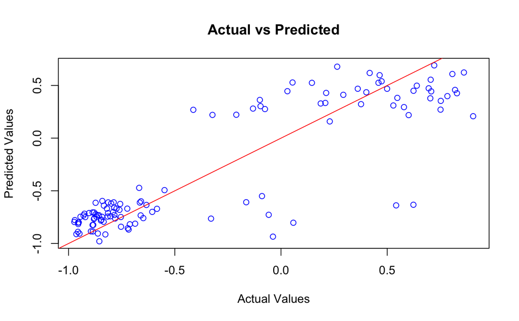

```r
real_model <- lm(real_selected[train_index, 1] ~ ., data = train_data)
predictions <- predict(real_model, newdata = test_data)
actual_values <- real_selected[-train_index, 1]

plot(actual_values, predictions, main = "Actual vs Predicted", xlab = "Actual Values", ylab = "Predicted Values", col = "blue")
abline(0, 1, col = "red")  # Y=x line (ideal scenario)
```

```r
summary_statistics(actual_values, predictions)
```

```
       MSE       RMSE        MAE         R2
0.09625465 0.31024933 0.21913895 0.75890443
```

```r
summary(real_model)
```

```
Call:
lm(formula = real_selected[train_index, 1] ~ ., data = train_data)

Residuals:
     Min       1Q   Median       3Q      Max
-0.89338 -0.14790 -0.03043  0.14375  1.14793

Coefficients:
                                            Estimate Std. Error t value Pr(>|t|)
(Intercept)                                -1.527859   0.179696  -8.502 1.54e-15 ***
length.of.patch                             0.029122   0.017605   1.654 0.099315 .
width.of.patch                              0.125736   0.037719   3.333 0.000984 ***
height.of.patch                             2.509804   1.952238   1.286 0.199739
height.of.substrate                         1.446942   0.163030   8.875  < 2e-16 ***
height.of.solder.resist.layer               0.563168   0.711598   0.791 0.429433
radius.of.the.probe                        -2.619627   1.638274  -1.599 0.111046
c_pad                                      -4.736554   2.402469  -1.972 0.049735 *
c_antipad                                   0.561281   0.774268   0.725 0.469161
c_probe                                     0.024619   0.154207   0.160 0.873281
dielectric.constant.of.substrate            0.061878   0.022855   2.707 0.007237 **
dielectric.constant.of.solder.resist.layer -0.008456   0.020096  -0.421 0.674280
---
Signif. codes:  0 ‘***’ 0.001 ‘**’ 0.01 ‘*’ 0.05 ‘.’ 0.1 ‘ ’ 1

Residual standard error: 0.274 on 257 degrees of freedom
Multiple R-squared:  0.8147,    Adjusted R-squared:  0.8068
F-statistic: 102.7 on 11 and 257 DF,  p-value: < 2.2e-16
```

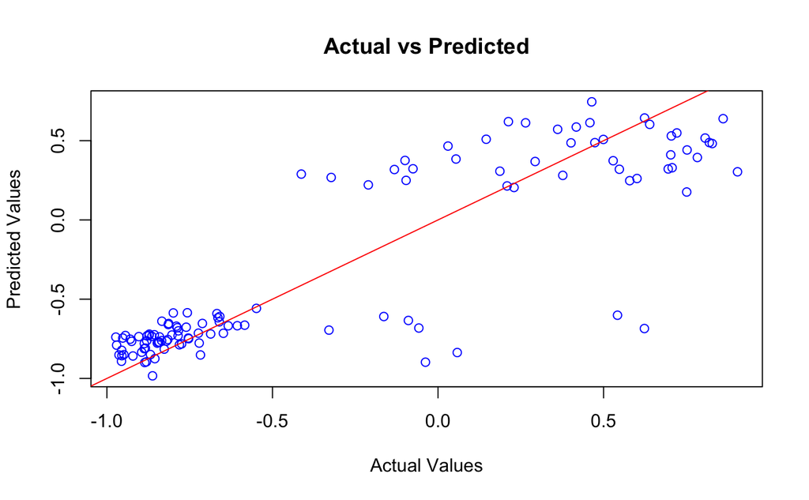

```r
calculate_mse <- function(actual, predicted) {
  mean((actual - predicted)^2)}
mse_values <- numeric(4)

real_model_1_v2 <- lm(real_selected[train_index, 1] ~ height.of.substrate * width.of.patch * dielectric.constant.of.substrate +
                                 radius.of.the.probe + c_probe, data = train_data)
predictions <- predict(real_model_1_v2, newdata = test_data)

actual_values <- real_selected[-train_index, 1]

plot(actual_values, predictions, main = "Actual vs Predicted", xlab = "Actual Values", ylab = "Predicted Values", col = "blue")
abline(0, 1, col = "red")
```

```r
summary_statistics(actual_values, predictions)
```

```
       MSE       RMSE        MAE         R2
0.09530739 0.30871895 0.20877483 0.76127708
```

```r
summary(real_model_1_v2)
```

```
Call:
lm(formula = real_selected[train_index, 1] ~ height.of.substrate *
    width.of.patch * dielectric.constant.of.substrate + radius.of.the.probe +
    c_probe, data = train_data)

Residuals:
     Min       1Q   Median       3Q      Max
-0.93120 -0.16215 -0.04222  0.12121  1.23263

Coefficients:
                                                                    Estimate Std. Error t value Pr(>|t|)
(Intercept)                                                         -2.84272    1.24999  -2.274   0.0238 *
height.of.substrate                                                 14.17004    7.84889   1.805   0.0722 .
width.of.patch                                                       0.39692    0.31403   1.264   0.2074
dielectric.constant.of.substrate                                     0.43554    0.31692   1.374   0.1705
radius.of.the.probe                                                 -2.40533    1.65349  -1.455   0.1470
c_probe                                                              0.07019    0.15891   0.442   0.6591
height.of.substrate:width.of.patch                                  -2.65948    1.64137  -1.620   0.1064
height.of.substrate:dielectric.constant.of.substrate                -3.29165    1.95571  -1.683   0.0936 .
width.of.patch:dielectric.constant.of.substrate                     -0.07125    0.08237  -0.865   0.3878
height.of.substrate:width.of.patch:dielectric.constant.of.substrate  0.68705    0.41013   1.675   0.0951 .
---
Signif. codes:  0 ‘***’ 0.001 ‘**’ 0.01 ‘*’ 0.05 ‘.’ 0.1 ‘ ’ 1

Residual standard error: 0.2753 on 259 degrees of freedom
Multiple R-squared:  0.8115,    Adjusted R-squared:  0.805
F-statistic: 123.9 on 9 and 259 DF,  p-value: < 2.2e-16
```

```r
mse_values[1] <- calculate_mse(actual_values, predictions)
```

**MSE Calculation for 4 Different Frequency Points:** Now we tested the model we established at 4 different frequencies and calculated the average MSE. As we can see in the output tables, the model we established according to the first frequency value showed similar performance at these frequency values.

```r
#Frequency 2:
real_model_1_v2 <- lm(real_selected[train_index, 2] ~ height.of.substrate * width.of.patch * dielectric.constant.of.substrate +
                                 radius.of.the.probe + c_probe, data = train_data)
predictions <- predict(real_model_1_v2, newdata = test_data)
actual_values <- real_selected[-train_index, 2]

summary_statistics(actual_values, predictions)
```

```
       MSE       RMSE        MAE         R2
0.09636196 0.31042223 0.21115067 0.75850417
```

```r
summary(real_model_1_v2)
```

```
Call:
lm(formula = real_selected[train_index, 2] ~ height.of.substrate *
    width.of.patch * dielectric.constant.of.substrate + radius.of.the.probe +
    c_probe, data = train_data)

Residuals:
     Min       1Q   Median       3Q      Max
-0.93402 -0.16266 -0.04245  0.14765  1.24776

Coefficients:
                                                                    Estimate Std. Error t value Pr(>|t|)
(Intercept)                                                         -2.95810    1.26351  -2.341   0.0200 *
height.of.substrate                                                 14.38645    7.93379   1.813   0.0709 .
width.of.patch                                                       0.43244    0.31742   1.362   0.1743
dielectric.constant.of.substrate                                     0.46612    0.32035   1.455   0.1469
radius.of.the.probe                                                 -2.28748    1.67138  -1.369   0.1723
c_probe                                                              0.09569    0.16063   0.596   0.5519
height.of.substrate:width.of.patch                                  -2.72575    1.65913  -1.643   0.1016
height.of.substrate:dielectric.constant.of.substrate                -3.33897    1.97687  -1.689   0.0924 .
width.of.patch:dielectric.constant.of.substrate                     -0.08178    0.08326  -0.982   0.3269
height.of.substrate:width.of.patch:dielectric.constant.of.substrate  0.70331    0.41457   1.696   0.0910 .
---
Signif. codes:  0 ‘***’ 0.001 ‘**’ 0.01 ‘*’ 0.05 ‘.’ 0.1 ‘ ’ 1

Residual standard error: 0.2783 on 259 degrees of freedom
Multiple R-squared:  0.8077,    Adjusted R-squared:  0.801
F-statistic: 120.8 on 9 and 259 DF,  p-value: < 2.2e-16
```

```r
mse_values[2] <- calculate_mse(actual_values, predictions)


#Frequency 3:
real_model_1_v2 <- lm(real_selected[train_index, 3] ~ height.of.substrate * width.of.patch * dielectric.constant.of.substrate +
                                 radius.of.the.probe + c_probe, data = train_data)
predictions <- predict(real_model_1_v2, newdata = test_data)
actual_values <- real_selected[-train_index, 3]

summary_statistics(actual_values, predictions)
```

```
       MSE       RMSE        MAE         R2
0.09393239 0.30648391 0.20607533 0.76486130
```

```r
summary(real_model_1_v2)
```

```
Call:
lm(formula = real_selected[train_index, 3] ~ height.of.substrate *
    width.of.patch * dielectric.constant.of.substrate + radius.of.the.probe +
    c_probe, data = train_data)

Residuals:
     Min       1Q   Median       3Q      Max
-0.92653 -0.15885 -0.04112  0.12953  1.19649

Coefficients:
                                                                    Estimate Std. Error t value Pr(>|t|)
(Intercept)                                                         -2.71672    1.23591  -2.198   0.0288 *
height.of.substrate                                                 13.88810    7.76047   1.790   0.0747 .
width.of.patch                                                       0.35908    0.31049   1.157   0.2485
dielectric.constant.of.substrate                                     0.40221    0.31335   1.284   0.2004
radius.of.the.probe                                                 -2.51200    1.63486  -1.537   0.1256
c_probe                                                              0.04305    0.15712   0.274   0.7843
height.of.substrate:width.of.patch                                  -2.57968    1.62288  -1.590   0.1132
height.of.substrate:dielectric.constant.of.substrate                -3.22692    1.93368  -1.669   0.0964 .
width.of.patch:dielectric.constant.of.substrate                     -0.06014    0.08144  -0.739   0.4609
height.of.substrate:width.of.patch:dielectric.constant.of.substrate  0.66725    0.40551   1.645   0.1011
---
Signif. codes:  0 ‘***’ 0.001 ‘**’ 0.01 ‘*’ 0.05 ‘.’ 0.1 ‘ ’ 1

Residual standard error: 0.2722 on 259 degrees of freedom
Multiple R-squared:  0.8156,    Adjusted R-squared:  0.8091
F-statistic: 127.2 on 9 and 259 DF,  p-value: < 2.2e-16
```

```r
mse_values[3] <- calculate_mse(actual_values, predictions)

#Frequency 4:
real_model_1_v2 <- lm(real_selected[train_index, 4] ~ height.of.substrate * width.of.patch * dielectric.constant.of.substrate +
                                 radius.of.the.probe + c_probe, data = train_data)
predictions <- predict(real_model_1_v2, newdata = test_data)
actual_values <- real_selected[-train_index, 4]

summary_statistics(actual_values, predictions)
```

```
       MSE       RMSE        MAE         R2
0.09682286 0.31116371 0.21320543 0.75708688
```

```r
summary(real_model_1_v2)
```

```
Call:
lm(formula = real_selected[train_index, 4] ~ height.of.substrate *
    width.of.patch * dielectric.constant.of.substrate + radius.of.the.probe +
    c_probe, data = train_data)

Residuals:
    Min      1Q  Median      3Q     Max
-0.9350 -0.1678 -0.0418  0.1487  1.2425

Coefficients:
                                                                    Estimate Std. Error t value Pr(>|t|)
(Intercept)                                                         -3.05965    1.27545  -2.399   0.0172 *
height.of.substrate                                                 14.52752    8.00879   1.814   0.0708 .
width.of.patch                                                       0.46471    0.32042   1.450   0.1482
dielectric.constant.of.substrate                                     0.49296    0.32338   1.524   0.1286
radius.of.the.probe                                                 -2.15236    1.68718  -1.276   0.2032
c_probe                                                              0.11887    0.16215   0.733   0.4641
height.of.substrate:width.of.patch                                  -2.77612    1.67481  -1.658   0.0986 .
height.of.substrate:dielectric.constant.of.substrate                -3.36624    1.99555  -1.687   0.0928 .
width.of.patch:dielectric.constant.of.substrate                     -0.09145    0.08405  -1.088   0.2776
height.of.substrate:width.of.patch:dielectric.constant.of.substrate  0.71537    0.41849   1.709   0.0886 .
---
Signif. codes:  0 ‘***’ 0.001 ‘**’ 0.01 ‘*’ 0.05 ‘.’ 0.1 ‘ ’ 1

Residual standard error: 0.2809 on 259 degrees of freedom
Multiple R-squared:  0.8043,    Adjusted R-squared:  0.7975
F-statistic: 118.2 on 9 and 259 DF,  p-value: < 2.2e-16
```

```r
mse_values[4] <- calculate_mse(actual_values, predictions)

average_mse <- mean(mse_values)
cat("Average MSE for all models:", average_mse, "\n")
```

```
Average MSE for all models: 0.09560615
```

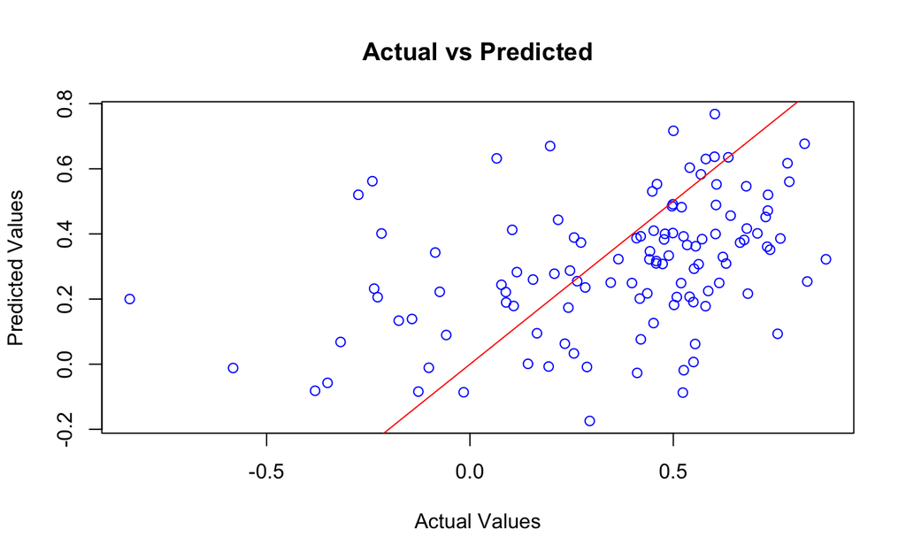

```r
img_model <- lm(img_selected[train_index, 1] ~ ., data = train_data)
predictions <- predict(img_model, newdata = test_data)
actual_values <- img_selected[-train_index, 1]

plot(actual_values, predictions, main = "Actual vs Predicted", xlab = "Actual Values", ylab = "Predicted Values", col = "blue")
abline(0, 1, col = "red")  # Y=x line (ideal scenario)
```

```r
summary_statistics(actual_values, predictions)
```

```
       MSE       RMSE        MAE         R2
0.09801304 0.31307035 0.24783553 0.08662008
```

```r
summary(img_model)
```

```
Call:
lm(formula = img_selected[train_index, 1] ~ ., data = train_data)

Residuals:
     Min       1Q   Median       3Q      Max
-1.12200 -0.13632  0.05006  0.18736  0.77277

Coefficients:
                                            Estimate Std. Error t value Pr(>|t|)
(Intercept)                                 0.555930   0.189911   2.927  0.00373 **
length.of.patch                            -0.011280   0.018606  -0.606  0.54489
width.of.patch                              0.115307   0.039863   2.893  0.00415 **
height.of.patch                             4.217451   2.063214   2.044  0.04196 *
height.of.substrate                        -0.998054   0.172297  -5.793 2.02e-08 ***
height.of.solder.resist.layer               0.208665   0.752049   0.277  0.78165
radius.of.the.probe                        -7.672420   1.731403  -4.431 1.39e-05 ***
c_pad                                       2.102318   2.539039   0.828  0.40844
c_antipad                                   0.530891   0.818282   0.649  0.51705
c_probe                                    -1.035324   0.162973  -6.353 9.56e-10 ***
dielectric.constant.of.substrate            0.022939   0.024155   0.950  0.34317
dielectric.constant.of.solder.resist.layer  0.001146   0.021239   0.054  0.95702
---
Signif. codes:  0 ‘***’ 0.001 ‘**’ 0.01 ‘*’ 0.05 ‘.’ 0.1 ‘ ’ 1

Residual standard error: 0.2896 on 257 degrees of freedom
Multiple R-squared:  0.3676,    Adjusted R-squared:  0.3405
F-statistic: 13.58 on 11 and 257 DF,  p-value: < 2.2e-16
```

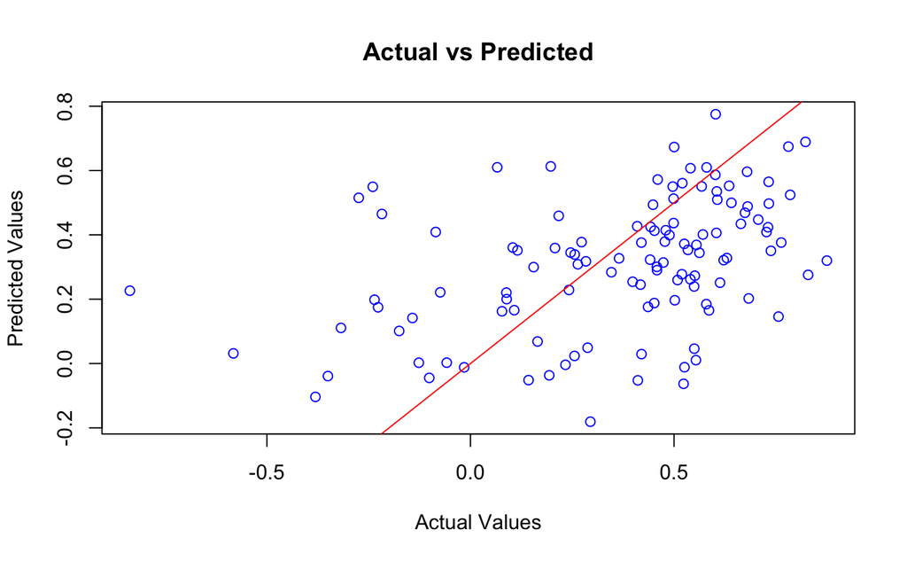

```r
mse_values_2 <- numeric(4)
img_model_v2 <- lm(img_selected[train_index, 1] ~ height.of.substrate + width.of.patch +
                                 radius.of.the.probe + c_probe, data = train_data)
predictions <- predict(img_model_v2, newdata = test_data)
actual_values <- img_selected[-train_index, 1]

plot(actual_values, predictions, main = "Actual vs Predicted", xlab = "Actual Values", ylab = "Predicted Values", col = "blue")
abline(0, 1, col = "red")  # Y=x line (ideal scenario)
```

```r
summary_statistics(actual_values, predictions)
```

```
       MSE       RMSE        MAE         R2
0.09573168 0.30940536 0.24144410 0.10788003
```

```r
summary(img_model_v2)
```

```
Call:
lm(formula = img_selected[train_index, 1] ~ height.of.substrate +
    width.of.patch + radius.of.the.probe + c_probe, data = train_data)

Residuals:
     Min       1Q   Median       3Q      Max
-1.03653 -0.13523  0.04205  0.17763  0.78814

Coefficients:
                    Estimate Std. Error t value Pr(>|t|)
(Intercept)          0.75838    0.11236   6.750 9.37e-11 ***
height.of.substrate -0.98431    0.16894  -5.826 1.64e-08 ***
width.of.patch       0.11999    0.03923   3.059  0.00245 **
radius.of.the.probe -7.60208    1.72605  -4.404 1.54e-05 ***
c_probe             -1.03717    0.16024  -6.473 4.67e-10 ***
---
Signif. codes:  0 ‘***’ 0.001 ‘**’ 0.01 ‘*’ 0.05 ‘.’ 0.1 ‘ ’ 1

Residual standard error: 0.2897 on 264 degrees of freedom
Multiple R-squared:  0.3501,    Adjusted R-squared:  0.3402
F-statistic: 35.55 on 4 and 264 DF,  p-value: < 2.2e-16
```

```r
mse_values_2[1] <- calculate_mse(actual_values, predictions)
```

```r
#Frequency 2:
img_model_v2 <- lm(real_selected[train_index, 2] ~ height.of.substrate * width.of.patch * dielectric.constant.of.substrate +
                                 radius.of.the.probe + c_probe, data = train_data)
predictions <- predict(img_model_v2, newdata = test_data)
actual_values <- real_selected[-train_index, 2]

summary_statistics(actual_values, predictions)
```

```
       MSE       RMSE        MAE         R2
0.09636196 0.31042223 0.21115067 0.75850417
```

```r
summary(img_model_v2)
```

```
Call:
lm(formula = real_selected[train_index, 2] ~ height.of.substrate *
    width.of.patch * dielectric.constant.of.substrate + radius.of.the.probe +
    c_probe, data = train_data)

Residuals:
     Min       1Q   Median       3Q      Max
-0.93402 -0.16266 -0.04245  0.14765  1.24776

Coefficients:
                                                                    Estimate Std. Error t value Pr(>|t|)
(Intercept)                                                         -2.95810    1.26351  -2.341   0.0200 *
height.of.substrate                                                 14.38645    7.93379   1.813   0.0709 .
width.of.patch                                                       0.43244    0.31742   1.362   0.1743
dielectric.constant.of.substrate                                     0.46612    0.32035   1.455   0.1469
radius.of.the.probe                                                 -2.28748    1.67138  -1.369   0.1723
c_probe                                                              0.09569    0.16063   0.596   0.5519
height.of.substrate:width.of.patch                                  -2.72575    1.65913  -1.643   0.1016
height.of.substrate:dielectric.constant.of.substrate                -3.33897    1.97687  -1.689   0.0924 .
width.of.patch:dielectric.constant.of.substrate                     -0.08178    0.08326  -0.982   0.3269
height.of.substrate:width.of.patch:dielectric.constant.of.substrate  0.70331    0.41457   1.696   0.0910 .
---
Signif. codes:  0 ‘***’ 0.001 ‘**’ 0.01 ‘*’ 0.05 ‘.’ 0.1 ‘ ’ 1

Residual standard error: 0.2783 on 259 degrees of freedom
Multiple R-squared:  0.8077,    Adjusted R-squared:  0.801
F-statistic: 120.8 on 9 and 259 DF,  p-value: < 2.2e-16
```

```r
mse_values_2[2] <- calculate_mse(actual_values, predictions)


#Frequency 3:
img_model_v2 <- lm(real_selected[train_index, 3] ~ height.of.substrate * width.of.patch * dielectric.constant.of.substrate +
                                 radius.of.the.probe + c_probe, data = train_data)
predictions <- predict(img_model_v2, newdata = test_data)
actual_values <- real_selected[-train_index, 3]

summary_statistics(actual_values, predictions)
```

```
       MSE       RMSE        MAE         R2
0.09393239 0.30648391 0.20607533 0.76486130
```

```r
summary(img_model_v2)
```

```
Call:
lm(formula = real_selected[train_index, 3] ~ height.of.substrate *
    width.of.patch * dielectric.constant.of.substrate + radius.of.the.probe +
    c_probe, data = train_data)

Residuals:
     Min       1Q   Median       3Q      Max
-0.92653 -0.15885 -0.04112  0.12953  1.19649

Coefficients:
                                                                    Estimate Std. Error t value Pr(>|t|)
(Intercept)                                                         -2.71672    1.23591  -2.198   0.0288 *
height.of.substrate                                                 13.88810    7.76047   1.790   0.0747 .
width.of.patch                                                       0.35908    0.31049   1.157   0.2485
dielectric.constant.of.substrate                                     0.40221    0.31335   1.284   0.2004
radius.of.the.probe                                                 -2.51200    1.63486  -1.537   0.1256
c_probe                                                              0.04305    0.15712   0.274   0.7843
height.of.substrate:width.of.patch                                  -2.57968    1.62288  -1.590   0.1132
height.of.substrate:dielectric.constant.of.substrate                -3.22692    1.93368  -1.669   0.0964 .
width.of.patch:dielectric.constant.of.substrate                     -0.06014    0.08144  -0.739   0.4609
height.of.substrate:width.of.patch:dielectric.constant.of.substrate  0.66725    0.40551   1.645   0.1011
---
Signif. codes:  0 ‘***’ 0.001 ‘**’ 0.01 ‘*’ 0.05 ‘.’ 0.1 ‘ ’ 1

Residual standard error: 0.2722 on 259 degrees of freedom
Multiple R-squared:  0.8156,    Adjusted R-squared:  0.8091
F-statistic: 127.2 on 9 and 259 DF,  p-value: < 2.2e-16
```

```r
mse_values_2[3] <- calculate_mse(actual_values, predictions)

#Frequency 4:
img_model_v2 <- lm(real_selected[train_index, 4] ~ height.of.substrate * width.of.patch * dielectric.constant.of.substrate +
                                 radius.of.the.probe + c_probe, data = train_data)
predictions <- predict(img_model_v2, newdata = test_data)
actual_values <- real_selected[-train_index, 4]

summary_statistics(actual_values, predictions)
```

```
       MSE       RMSE        MAE         R2
0.09682286 0.31116371 0.21320543 0.75708688
```

```r
summary(img_model_v2)
```

```
Call:
lm(formula = real_selected[train_index, 4] ~ height.of.substrate *
    width.of.patch * dielectric.constant.of.substrate + radius.of.the.probe +
    c_probe, data = train_data)

Residuals:
    Min      1Q  Median      3Q     Max
-0.9350 -0.1678 -0.0418  0.1487  1.2425

Coefficients:
                                                                    Estimate Std. Error t value Pr(>|t|)
(Intercept)                                                         -3.05965    1.27545  -2.399   0.0172 *
height.of.substrate                                                 14.52752    8.00879   1.814   0.0708 .
width.of.patch                                                       0.46471    0.32042   1.450   0.1482
dielectric.constant.of.substrate                                     0.49296    0.32338   1.524   0.1286
radius.of.the.probe                                                 -2.15236    1.68718  -1.276   0.2032
c_probe                                                              0.11887    0.16215   0.733   0.4641
height.of.substrate:width.of.patch                                  -2.77612    1.67481  -1.658   0.0986 .
height.of.substrate:dielectric.constant.of.substrate                -3.36624    1.99555  -1.687   0.0928 .
width.of.patch:dielectric.constant.of.substrate                     -0.09145    0.08405  -1.088   0.2776
height.of.substrate:width.of.patch:dielectric.constant.of.substrate  0.71537    0.41849   1.709   0.0886 .
---
Signif. codes:  0 ‘***’ 0.001 ‘**’ 0.01 ‘*’ 0.05 ‘.’ 0.1 ‘ ’ 1

Residual standard error: 0.2809 on 259 degrees of freedom
Multiple R-squared:  0.8043,    Adjusted R-squared:  0.7975
F-statistic: 118.2 on 9 and 259 DF,  p-value: < 2.2e-16
```

```r
mse_values_2[4] <- calculate_mse(actual_values, predictions)

average_mse <- mean(mse_values)
cat("Average MSE for all models:", average_mse, "\n")
```

```
Average MSE for all models: 0.09560615
```

**PCA:** For PC1, the most important variables are width.of.patch and height.of.substrate, with very similar contributions. PC2 is dominated by c_probe and c_antipad, followed by the dielectric.constant.of.solder.resist.layer. PC3 emphasizes height.of.patch and radius.of.the.probe, with length.of.patch also contributing significantly. PC4 highlights height.of.solder.resist.layer and radius.of.the.probe, with height.of.patch and length.of.patch contributing moderately.

```r
input_data_scaled <- scale(input_data)
pca_model <- prcomp(input_data_scaled, center = TRUE, scale. = TRUE)
summary(pca_model)
```

```
Importance of components:
                          PC1    PC2    PC3     PC4     PC5     PC6     PC7     PC8    PC9   PC10    PC11
Standard deviation     1.5095 1.1035 1.0490 1.02801 1.00528 0.98643 0.97070 0.94771 0.8985 0.8008 0.27132
Proportion of Variance 0.2072 0.1107 0.1000 0.09607 0.09187 0.08846 0.08566 0.08165 0.0734 0.0583 0.00669
Cumulative Proportion  0.2072 0.3179 0.4179 0.51397 0.60584 0.69430 0.77996 0.86161 0.9350 0.9933 1.00000
```

```r
pca_df <- as.data.frame(pca_model$x)
pca_loadings <- pca_model$rotation

top_features <- list()
for (i in 1:4) {
  top_features[[paste0("PC", i)]] <- head(sort(abs(pca_loadings[, i]), decreasing = TRUE), 5)
}

print(top_features)
```

```
$PC1
                  width.of.patch              height.of.substrate dielectric.constant.of.substrate                  length.of.patch
                      0.62417829                       0.62413737                       0.44510015                       0.10132741
                 height.of.patch
                      0.07105448

$PC2
                                   c_probe                                  c_antipad dielectric.constant.of.solder.resist.layer
                                 0.5647532                                  0.5594987                                  0.3509443
                           length.of.patch              height.of.solder.resist.layer
                                 0.3154088                                  0.2662590

$PC3
                           height.of.patch                        radius.of.the.probe                            length.of.patch
                                 0.6204605                                  0.5483814                                  0.3696453
          dielectric.constant.of.substrate dielectric.constant.of.solder.resist.layer
                                 0.2561670                                  0.2553394

$PC4
height.of.solder.resist.layer           radius.of.the.probe               height.of.patch               length.of.patch
                    0.5106525                     0.4543966                     0.3929743                     0.3768830
                    c_antipad
                    0.3739261
```

```r
variances <- pca_model$sdev^2

variances_explained <- variances / sum(variances)

cat("Explained Variance for the First 4 Components:\n")
```

```
Explained Variance for the First 4 Components:
```

```r
explained_variance <- data.frame(
  Component = paste0("PC", 1:4),
  Variance_Explained = variances_explained[1:4],
  Cumulative_Variance = cumsum(variances_explained)[1:4]
)
explained_variance
```

| Component | Variance_Explained | Cumulative_Variance |
| --- | --- | --- |
| PC1 | 0.20715348 | 0.2071535 |
| PC2 | 0.11070825 | 0.3178617 |
| PC3 | 0.10003384 | 0.4178956 |
| PC4 | 0.09607237 | 0.5139679 |

```r
num_components <- which(cumsum_variances_explained >= 0.5)[1]
cat("Number of Selected Components: ", num_components, "\n")
```

```
Number of Selected Components:  4
```

**Regression Modeling for S11:** Linear regression models have shown varying success in predicting the real and imaginary components of S11 based on the geometric parameters of the antenna design. The model we created for the real component shows a very high accuracy with the R-squared value calculated as 76.13%. The error metrics of this model also provided very good results. MSE (Mean Squared Error) was determined as 0.0953, RMSE (Root Mean Squared Error) as 0.3087, and MAE (Mean Absolute Error) as 0.2088. In addition, the R2 value was 0.7613, meaning that the model can predict with 76% accuracy. This result shows that the model is successful and the design parameters have a strong effect on the real component of S11.

However, the model we created for the imaginary component showed lower accuracy. The R-squared value remained at only 10.79%, which reveals how weak the model is in predicting the imaginary component. The error metrics calculated for the imaginary component are: MSE 0.0957, RMSE 0.3094, and MAE 0.2414. The R2 value was found to be only 0.1079. This situation shows that the imaginary component requires more complex relationships and the model cannot learn such relationships effectively enough.

In general, it can be said that the real component model is more successful with higher accuracy and lower error metrics. The low accuracy in the imaginary component model indicates that more advanced analyses or more in-depth examination of parameter interactions are required. Therefore, more sophisticated models or analyses that take into account the interactions of parameters can provide better results for predicting the imaginary component.

**DIMENSIONALITY REDUXTION WITH PCA:** PC1 (First Component): The parameters with high loading in this component are geometric parameters such as “width.of.patch”, “height.of.substrate”, “dielectric.constant.of.substrate” (substrate dielectric constant). This shows that geometric shapes (especially patch dimensions and substrate properties) have a significant effect on electromagnetic behavior. It is understood that patch dimensions and substrate properties can affect the propagation of the electromagnetic field and how energy is transmitted.

PC2 (Second Component): In this component, parameters such as “c_probe” (probe capacity), “c_antipad” (antipad capacity), “dielectric.constant.of.solder.resist.layer” (solder mask dielectric constant) come to the fore. This suggests that the dielectric properties of structural elements such as probe and antipad and the locations of these elements are strongly related to the electromagnetic behavior. In particular, the dielectric constant can affect the electrical conductivity and field distribution associated with such structures.

PC3 and PC4 (Third and Fourth Components): These components are mostly related to parameters such as “height.of.patch”, “length.of.patch”, “radius.of.the.probe”. It shows that geometric dimensions reflect the effects of probe and patch designs in particular on the propagation of the electromagnetic field. These parameters may include small-scale variables that are effective at high frequencies and change the electromagnetic behavior.

According to the results provided by PCA, geometric parameters (e.g. patch dimensions, substrate properties) seem to be one of the most important factors shaping the electromagnetic behavior. Especially parameters such as patch width, length and height can have a direct effect on the propagation and transmission of the electromagnetic field. Such parameters can affect critical properties such as antenna efficiency, signal transmission and resonant frequencies.

Trying to determine the parameters affecting the S11 response of the antenna using PCA (Principal Component Analysis) can be an important method in terms of simplifying the design space, but in our case this method was not as effective as expected. Because, while 8 main components were needed to explain 80% of the variance, this created too much complexity in the design. This situation shows that PCA does not simplify the design process in every case. For a better solution, we focused on four main components that would explain only 50% of the variance. Although this provided a simpler model, it can be said that PCA has a limited effect in this specific case.

As a result, although PCA is useful in understanding the effect of the design parameters, it may not be effective in reducing complexity in every case. Instead, it may be necessary to improve the design process with different modeling or analysis methods.

*For the syntax of R codes, the codes in the course and GenAI tools were referenced.*